# Gower_tSNE

Vijai Kasthuri Rangan

### Introduction

The following is an illustrative example of using ‘gower’ distance to cluster mixed type data and using tSNE for visualizing the clusters. There are several distance measures that one can use for determing the (dis) similarity of one observation to another. The euclidean distance measure is used when we have continous variables, while ‘gower’ and manhattan distances are common for categorical and high dimensional variables respectively.

In the following example we use the ‘college’ dataset available from ISLR library to segement the 777 colleges using an unsupervised learning approach.

Load the required libraries

```r
library(dplyr)
library(ISLR) #college dataset
library(cluster) #cluster analysis (PAM)
library(Rtsne) #tSNE
library(ggplot2)

set.seed(1)
```

### Dataset

Using the college dataset, create buckets based on top10perc to categorize the colleges as “Elite” or “Not Elite”. Any college with more than 50 top 10 percentile students in its enrollees have be considered as elite. Subset the data to only the required columns - here only name, acceptance rate, outstate, enroll, graduate rate, private indicator and Elite flags are included

```r
college_clean <- College %>% mutate(name=row.names(.), Acc_rate = Accept/Apps,
                                    isElite = cut(Top10perc, breaks=c(0,50,100), labels = c("Not Elite", "Elite"), include.lowest = TRUE)) %>%
  mutate(isElite=factor(isElite)) %>% select(name, Acc_rate, Outstate, Enroll, Grad.Rate, Private, isElite)

glimpse(college_clean)
```

```
## Observations: 777
## Variables: 7
## $ name      <chr> "Abilene Christian University", "Adelphi University"...
## $ Acc_rate  <dbl> 0.7421687, 0.8801464, 0.7682073, 0.8369305, 0.756476...
## $ Outstate  <dbl> 7440, 12280, 11250, 12960, 7560, 13500, 13290, 13868...
## $ Enroll    <dbl> 721, 512, 336, 137, 55, 158, 103, 489, 227, 172, 472...
## $ Grad.Rate <dbl> 60, 56, 54, 59, 15, 55, 63, 73, 80, 52, 73, 76, 74, ...
## $ Private   <fctr> Yes, Yes, Yes, Yes, Yes, Yes, Yes, Yes, Yes, Yes, Y...
## $ isElite   <fctr> Not Elite, Not Elite, Not Elite, Elite, Not Elite, ...
```

On exploring the data we see that the number of enrollees are right skewed and it might make sense to log transform this variable

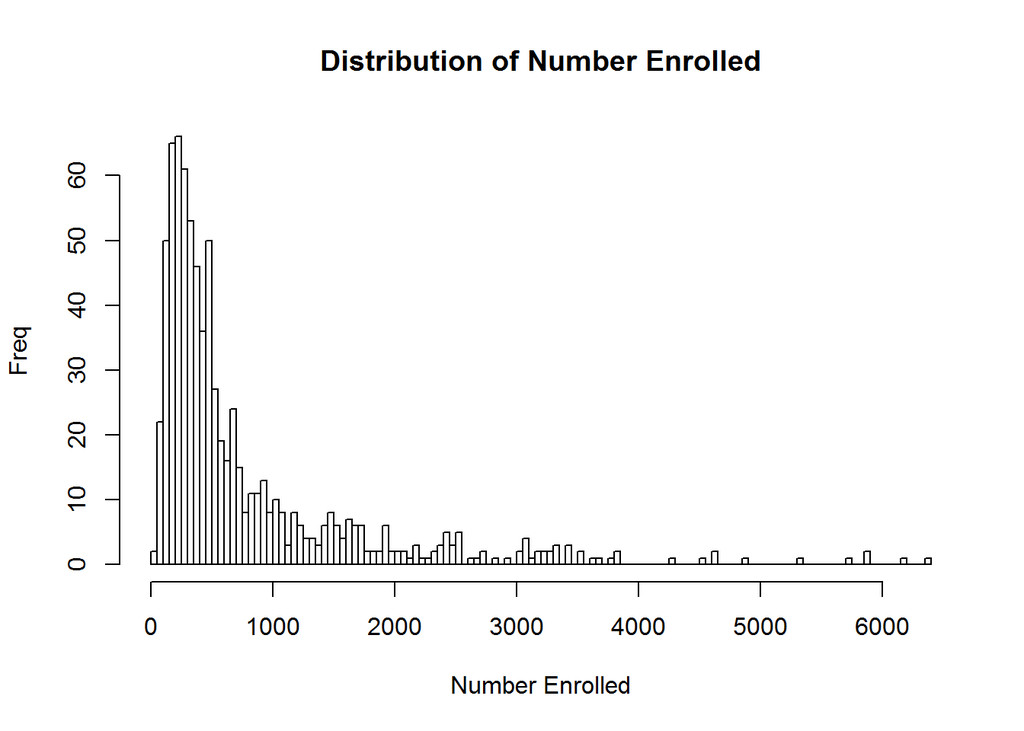

```r
hist((college_clean$Enroll), 100, main="Distribution of Number Enrolled", xlab = 'Number Enrolled', ylab='Freq')
```

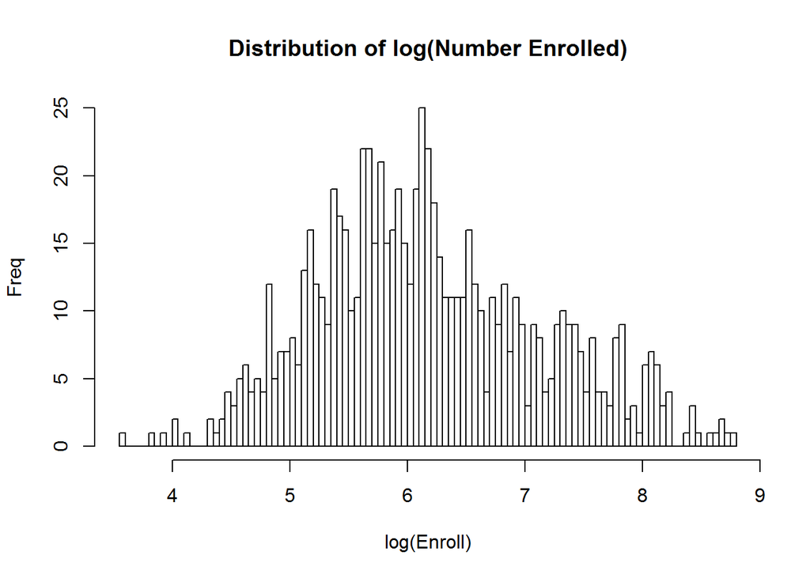

```r
hist(log(college_clean$Enroll), 100, main="Distribution of log(Number Enrolled)", xlab = 'log(Enroll)', ylab='Freq')
```

### Distance Matrix

Compute the distance matrix using the ‘daisy’ function with the metric as ‘gower’. The Gower distances are calculated for nominal, ordinal, and (a)symmetric data. All variables are standardized and scaled to a value between [0,1] and the dissimilarity between two observations with categorical variables is the weighted mean of the contributions of each variable. .

```r
gower_dist <- daisy(college_clean[,-1], metric = 'gower', type = list(logratio = 3))
gower_mat <- as.matrix(gower_dist)

# Output most similar pair

college_clean[
  which(gower_mat == min(gower_mat[gower_mat != min(gower_mat)]),
        arr.ind = TRUE)[1, ], ]
```

```
##                            name  Acc_rate Outstate Enroll Grad.Rate
## 682 University of St. Thomas MN 0.8784638    11712    828        89
## 284     John Carroll University 0.8711276    11700    820        89
##     Private   isElite
## 682     Yes Not Elite
## 284     Yes Not Elite
```

```r
# dis similar pair

college_clean[
  which(gower_mat == max(gower_mat[gower_mat != max(gower_mat)]),
        arr.ind = TRUE)[1, ], ]
```

```
##                                        name  Acc_rate Outstate Enroll
## 673 University of Sci. and Arts of Oklahoma 0.9824561     3687    208
## 251                      Harvard University 0.1561486    18485   1606
##     Grad.Rate Private   isElite
## 673        43      No Not Elite
## 251       100     Yes     Elite
```

### Clusters

To determine the number of clusters, we use the silhoutte width which peaks at 3. We cluster the data using PAM (partitioning around mediods). This algorithm is a k-mediods version of the well know k-means algorithm.

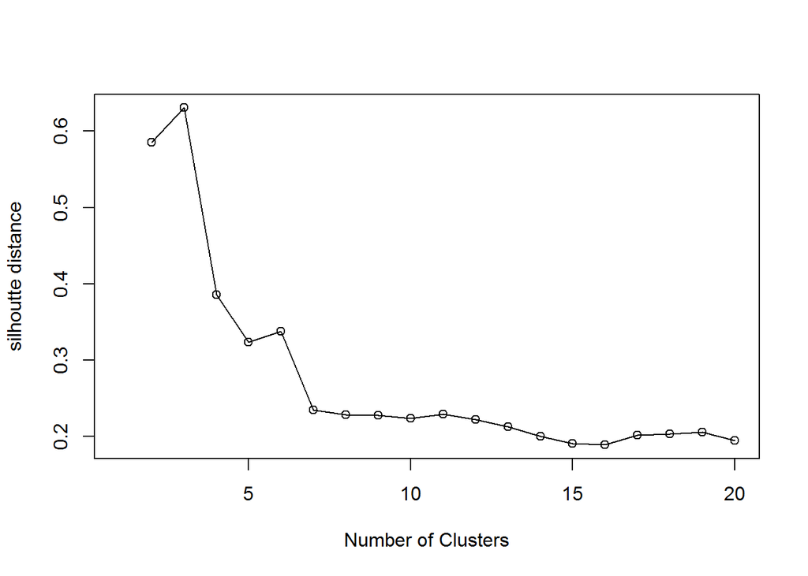

```r
# silhoutte width to determine number of clusters

sil_width <- c(NA)
for(i in 2:20){
  pam_fit <- pam(gower_dist, diss=TRUE, k=i)
  sil_width[i] <- pam_fit$silinfo$avg.width
}


plot(1:20, sil_width, xlab = "Number of Clusters", ylab="silhoutte distance")
lines(1:20, sil_width)
```

```r
pam_fit <- pam(gower_dist, diss=TRUE, k=3)
college_clean$cluster <- pam_fit$clustering
```

What do the different clusters look like?

```r
pam_summary <- college_clean %>% group_by(cluster) %>% do(the_summary = summary(.))
pam_summary$the_summary
```

```
## [[1]]
##      name              Acc_rate         Outstate         Enroll
##  Length:500         Min.   :0.3283   Min.   : 2340   Min.   :  35.0
##  Class :character   1st Qu.:0.7225   1st Qu.: 8842   1st Qu.: 194.8
##  Mode  :character   Median :0.8004   Median :10905   Median : 308.0
##                     Mean   :0.7820   Mean   :11200   Mean   : 418.6
##                     3rd Qu.:0.8581   3rd Qu.:13240   3rd Qu.: 484.8
##                     Max.   :1.0000   Max.   :21700   Max.   :4615.0
##    Grad.Rate      Private        isElite       cluster
##  Min.   : 15.00   No :  0   Not Elite:500   Min.   :1
##  1st Qu.: 56.00   Yes:500   Elite    :  0   1st Qu.:1
##  Median : 67.50                             Median :1
##  Mean   : 66.97                             Mean   :1
##  3rd Qu.: 78.25                             3rd Qu.:1
##  Max.   :118.00                             Max.   :1
##
## [[2]]
##      name              Acc_rate         Outstate         Enroll
##  Length:69          Min.   :0.1545   Min.   : 5224   Min.   : 137.0
##  Class :character   1st Qu.:0.4135   1st Qu.:13850   1st Qu.: 391.0
##  Mode  :character   Median :0.5329   Median :17238   Median : 601.0
##                     Mean   :0.5392   Mean   :16225   Mean   : 882.5
##                     3rd Qu.:0.6988   3rd Qu.:18590   3rd Qu.:1191.0
##                     Max.   :0.9605   Max.   :20100   Max.   :4893.0
##    Grad.Rate      Private       isElite      cluster
##  Min.   : 54.00   No : 4   Not Elite: 0   Min.   :2
##  1st Qu.: 77.00   Yes:65   Elite    :69   1st Qu.:2
##  Median : 89.00                           Median :2
##  Mean   : 84.78                           Mean   :2
##  3rd Qu.: 94.00                           3rd Qu.:2
##  Max.   :100.00                           Max.   :2
##
## [[3]]
##      name              Acc_rate         Outstate         Enroll
##  Length:208         Min.   :0.3746   Min.   : 2580   Min.   : 153
##  Class :character   1st Qu.:0.6423   1st Qu.: 5295   1st Qu.: 694
##  Mode  :character   Median :0.7458   Median : 6598   Median :1302
##                     Mean   :0.7315   Mean   : 6698   Mean   :1615
##                     3rd Qu.:0.8368   3rd Qu.: 7748   3rd Qu.:2184
##                     Max.   :1.0000   Max.   :15516   Max.   :6392
##    Grad.Rate      Private        isElite       cluster
##  Min.   : 10.00   No :208   Not Elite:199   Min.   :3
##  1st Qu.: 46.00   Yes:  0   Elite    :  9   1st Qu.:3
##  Median : 54.50                             Median :3
##  Mean   : 55.42                             Mean   :3
##  3rd Qu.: 65.00                             3rd Qu.:3
##  Max.   :100.00                             Max.   :3
```

We see that the first cluster is a grouping of Non elite private colleges, while the second is Elite private and the third is majorly public non elite colleges

### t-SNE

Plotting a tSNE (t-distributed stochastic neighbor embedding - a dimensionality reduction method (n -> 2) using probability distribution over pairs of high dimensional objects) visual of this dataset shows the three groups along with an interesting small mix of groups 2 and 3

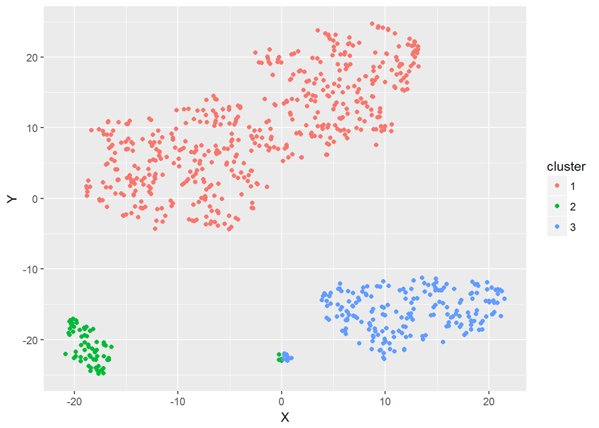

```r
tsne_obj <- Rtsne(gower_dist, distance=TRUE)
tnse_data <- tsne_obj$Y %>% data.frame() %>% setNames(c("X","Y")) %>% mutate(cluster = factor(pam_fit$clustering), name = college_clean$name)

ggplot(aes(x=X, y=Y,), data=tnse_data)+geom_point(aes(color=cluster, label=name))
```

##### Inspired from http://dpmartin42.github.io/blogposts/r/cluster-mixed-types